# COVID-19 LA County City-level Analysis

David Conti

18 October 2021

# The Data.

City-level information pulled from the following sources:

LA Almanac (race, age, and income) [http://www.laalmanac.com/population/po38.php](https://urldefense.com/v3/__http://www.laalmanac.com/population/po38.php__;!!LIr3w8kk_Xxm!42SFJ4mAnuyis5fMPAQR7pZQrdUOdIXm5lYMIzk-GKLmIJg3ELL6B5IHUolnOME$) [http://www.laalmanac.com/employment/em12.php](https://urldefense.com/v3/__http://www.laalmanac.com/employment/em12.php__;!!LIr3w8kk_Xxm!42SFJ4mAnuyis5fMPAQR7pZQrdUOdIXm5lYMIzk-GKLmIJg3ELL6B5IHVWwccds$)

LA County vaccine percent by city [http://publichealth.lacounty.gov/media/coronavirus/vaccine/vaccine-dashboard.htm](https://urldefense.com/v3/__http://publichealth.lacounty.gov/media/coronavirus/vaccine/vaccine-dashboard.htm__;!!LIr3w8kk_Xxm!42SFJ4mAnuyis5fMPAQR7pZQrdUOdIXm5lYMIzk-GKLmIJg3ELL6B5IHDgAHgCs$)

LA County age adjusted incidence rates [http://dashboard.publichealth.lacounty.gov/covid19_surveillance_dashboard/](https://urldefense.com/v3/__http://dashboard.publichealth.lacounty.gov/covid19_surveillance_dashboard/__;!!LIr3w8kk_Xxm!42SFJ4mAnuyis5fMPAQR7pZQrdUOdIXm5lYMIzk-GKLmIJg3ELL6B5IHkw3Fuxs$)

Data are incidence rates (proportions), vaccination rates (proportions), and characteristics by city.

# Hypotheses:

All hypothesis are on the city-level and care must be taken when interpreting the results as they describe city-level variation and not individual level variation or co-variation.

**Investigation of the December 2020-January 2021 peak for COVID 19 captured by a single day for incidence rates: 2021-01-07:**

1. How do race/ethnicity, age, and income describe variation in incidence rates?

**Investigation of the August 2021 peak for COVID 19 captured by a single day for incidence rates: 2021-08-18:**

2. How do August vaccination proportions, race/ethnicity, age, income, and incidence rates for the Dec.-Jan. peak describe variation in incidence rates during the August peak for COVID 19?

**Investigation of August 2021 vaccination rates for COVID 19 captured by a single day for vaccination rates: 2021-08-18:**

3. How do race/ethnicity, age, income, and incidence rates for the Dec.-Jan. peak describe variation in August vaccination rates?

# Variable Distributions and Coding

## Cities

```r
city.populations <- data.frame(d$city, d$population.x)
names(city.populations) <- c("City", "Population_Size")
city.populations <- city.populations[order(city.populations$Population_Size, decreasing=T), ]
kable(city.populations, format = "simple", align = 'c', caption = "Cities and Population Size")
```

Cities and Population Size

|  | City | Population_Size |
| --- | --- | --- |
| 67 | Los Angeles | 4043337 |
| 94 | Santa Clarita | 220424 |
| 43 | Glendale | 206493 |
| 61 | Lancaster | 161570 |
| 77 | Palmdale | 158968 |
| 81 | Pomona | 155931 |
| 107 | Torrance | 149268 |
| 33 | East Los Angeles | 125269 |
| 38 | El Monte | 117269 |
| 31 | Downey | 114263 |
| 51 | Inglewood | 113582 |
| 113 | West Covina | 108235 |
| 76 | Norwalk | 107622 |
| 16 | Burbank | 107180 |
| 24 | Compton | 99904 |
| 100 | South Gate | 98155 |
| 18 | Carson | 93846 |
| 96 | Santa Monica | 92446 |
| 47 | Hawthorne | 88787 |
| 119 | Whittier | 87432 |
| 4 | Alhambra | 86724 |
| 60 | Lakewood | 80362 |
| 14 | Bellflower | 77735 |
| 11 | Baldwin Park | 76769 |
| 68 | Lynwood | 72047 |
| 84 | Redondo Beach | 68697 |
| 41 | Florence-Graham | 64705 |
| 74 | Montebello | 64375 |
| 80 | Pico Rivera | 64284 |
| 75 | Monterey Park | 62262 |

[output cut: 90 more lines]

```r
City <- d$city
```

## Incidence Rates

### January Peak: 2021-01-07

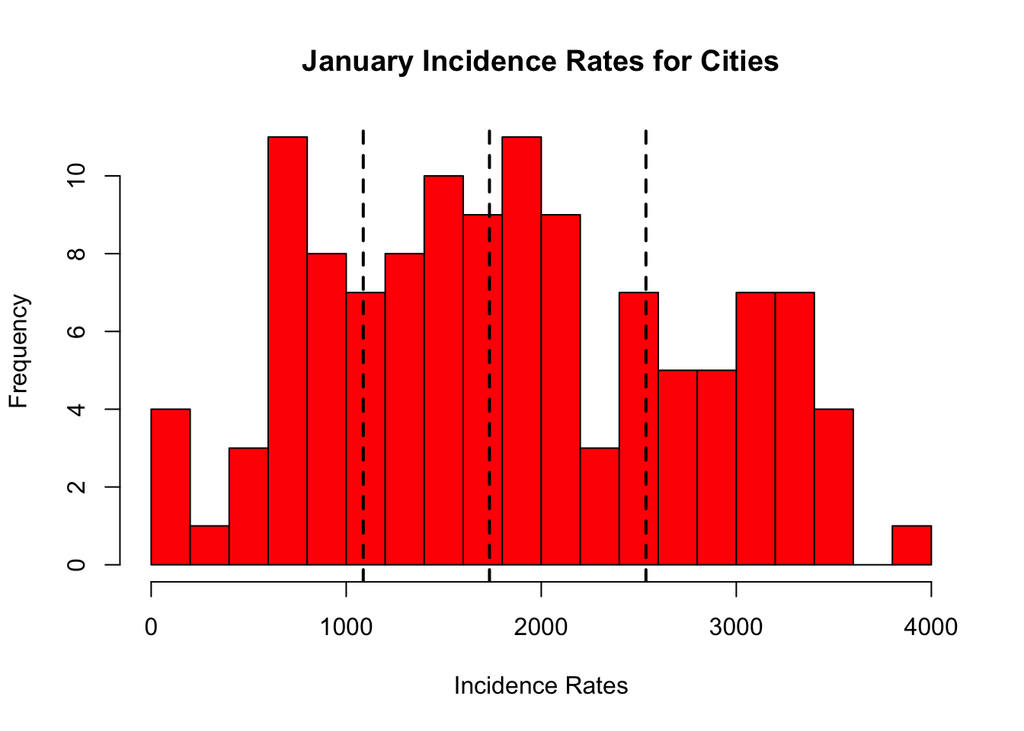

```r
Jan.IR <- d$adj_case_14day_rate.x
Jan.IR.cat <- relevel(as.factor(ifelse(Jan.IR > quantile(Jan.IR, probs=.75), "High",
                      ifelse(Jan.IR < quantile(Jan.IR, probs=.25), "Low",
                             "Med"))), ref="Med")

hist(Jan.IR, breaks=seq(from=0, to=round(max(Jan.IR),-3), by=200), col="red", main="January Incidence Rates for Cities", xlab="Incidence Rates")
abline(v=quantile(Jan.IR, probs=c(.25, .5, .75)), lwd=2, lty=2)
```

### August Peak: 2021-08-18

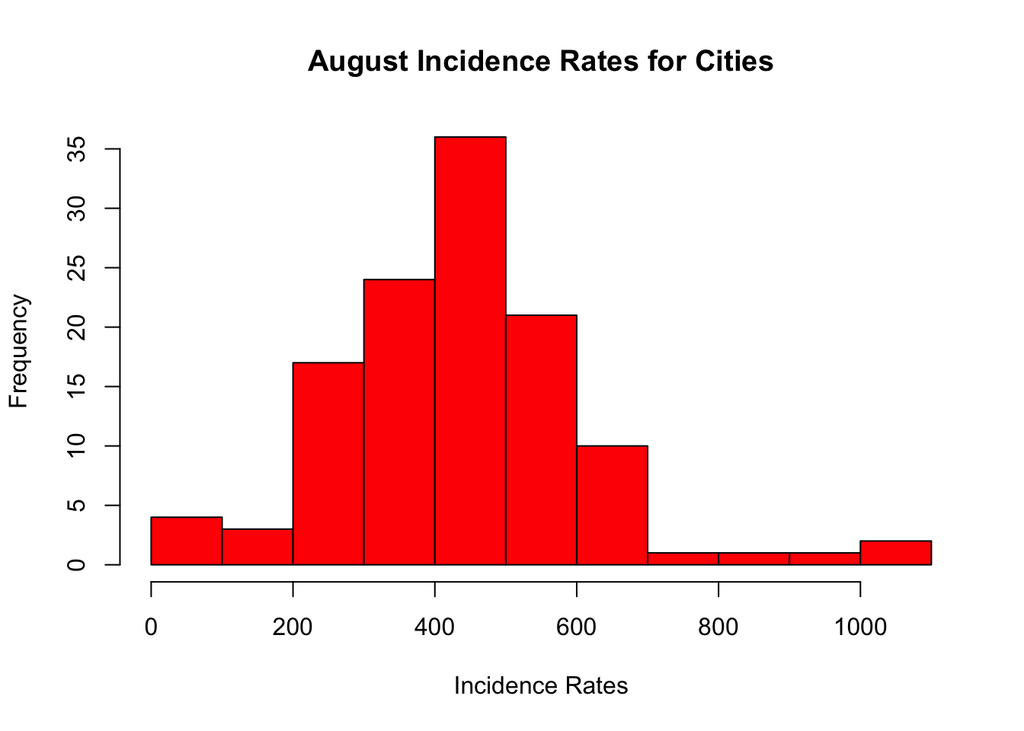

```r
Aug.IR <- d$adj_case_14day_rate.y

hist(Aug.IR, breaks=seq(from=0, to=round(max(Aug.IR),-2), by=100), col="red", main="August Incidence Rates for Cities", xlab="Incidence Rates")
```

## Percent Vaccinated in Each City

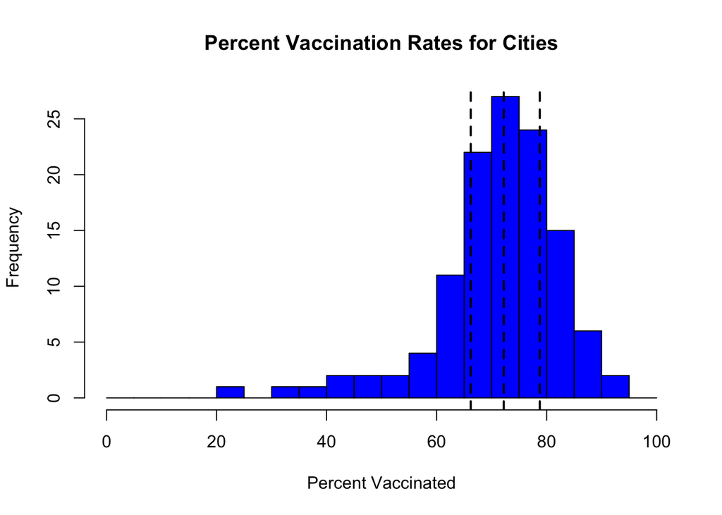

```r
Aug.Vax.percent <- as.numeric(unlist(strsplit(d$dose1_all_c_prcent, "%")))
Aug.Vax.cat <- relevel(as.factor(ifelse(Aug.Vax.percent > quantile(Aug.Vax.percent, probs=.75), "High",
                      ifelse(Aug.Vax.percent < quantile(Aug.Vax.percent, probs=.25), "Low",
                             "Med"))), ref="Med")

hist(Aug.Vax.percent, breaks=seq(from=0, to=100, by=5), col="blue", main="Percent Vaccination Rates for Cities", xlab="Percent Vaccinated")
abline(v=quantile(Aug.Vax.percent, probs=c(.25, .5, .75)), lwd=2, lty=2)
```

## Race/Ethnicity

### Proportion of Hispanic Individuals

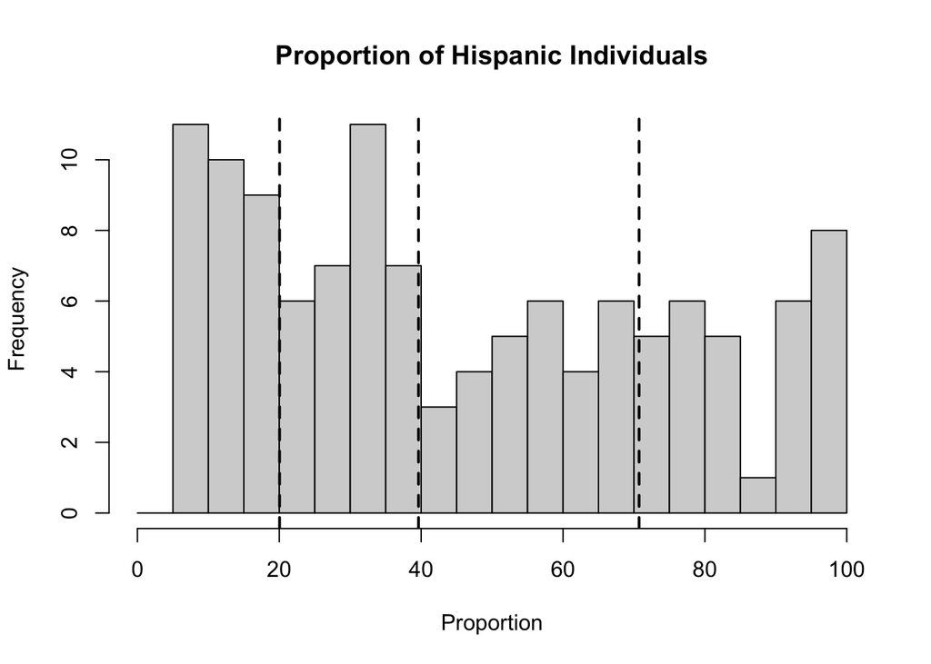

```r
CityHispanic <- d$Hispanic
CityHispanic.cat <- relevel(as.factor(ifelse(d$Hispanic > quantile(d$Hispanic, probs=.75), "High",
                      ifelse(d$Hispanic < quantile(d$Hispanic, probs=.25), "Low",
                             "Med"))), ref="Med")

hist(CityHispanic, breaks=seq(from=0, to=100, by=5), main="Proportion of Hispanic Individuals", xlab="Proportion")
abline(v=quantile(CityHispanic, probs=c(.25, .5, .75)), lwd=2, lty=2)
```

### Proportion of Black Individuals

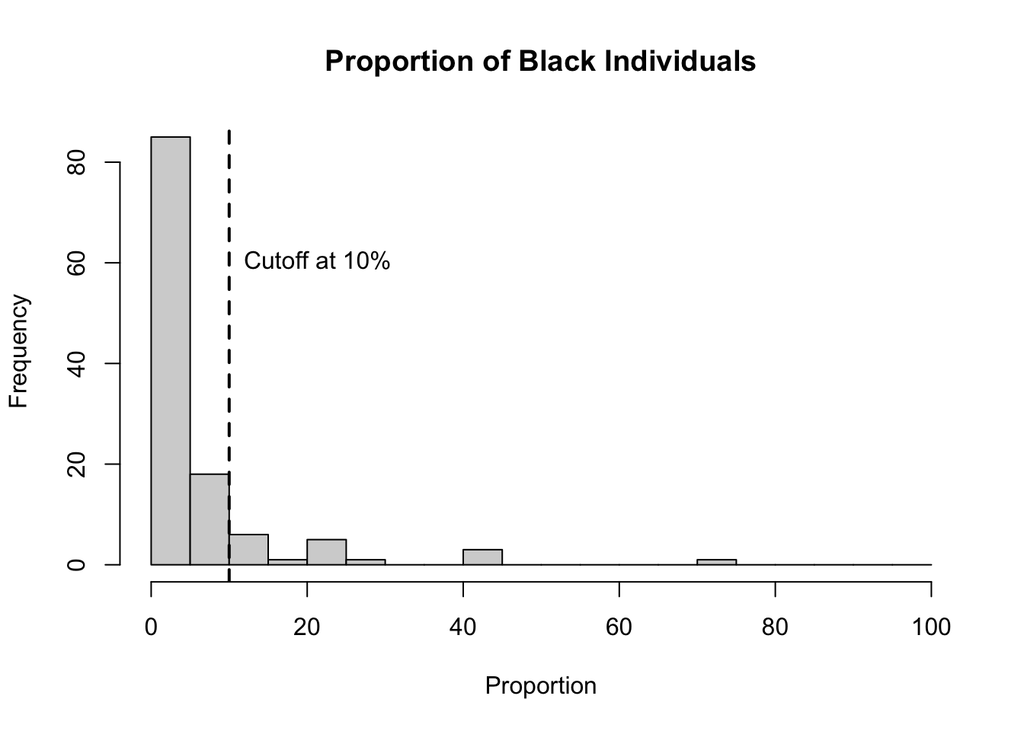

```r
CityBlack <- d$Black
CityBlack.cat <- relevel(as.factor(ifelse(d$Black > 10, "High","Low")), "Low")


hist(CityBlack, breaks=seq(from=0, to=100, by=5), main="Proportion of Black Individuals", xlab="Proportion")
abline(v=10, lwd=2, lty=2)
text(10, 60, "Cutoff at 10%", pos=4)
```

### Proportion of Asian Individuals

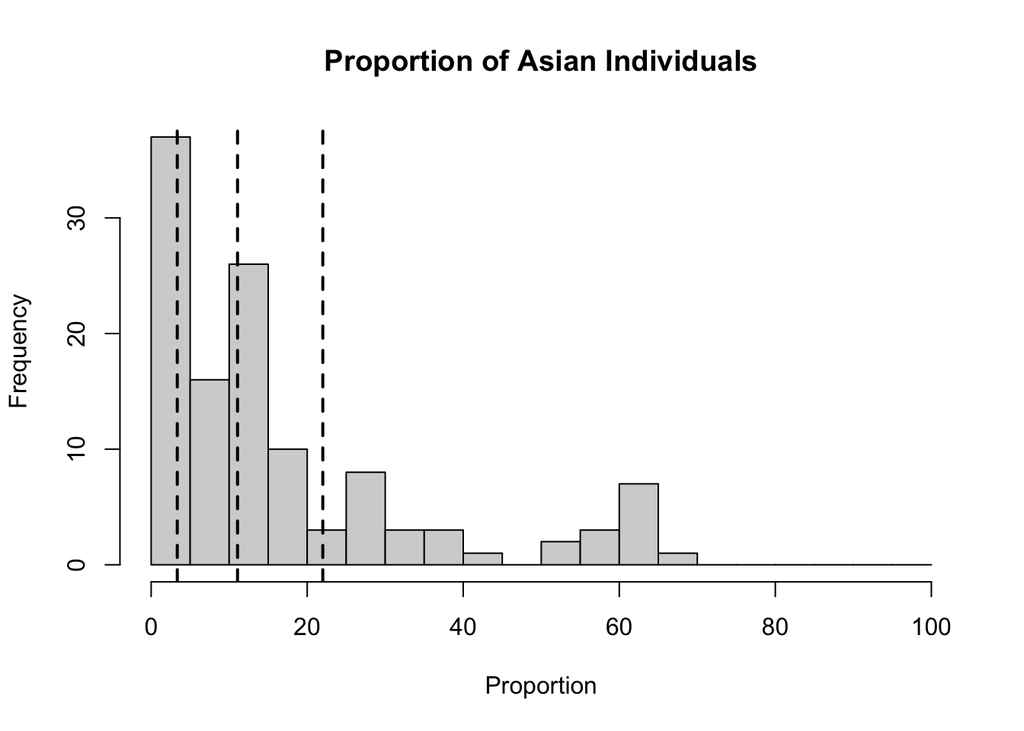

```r
CityAsian <- d$Asian
CityAsian.cat <- relevel(as.factor(ifelse(d$Asian > quantile(d$Asian, probs=.75), "High",
                      ifelse(d$Asian < quantile(d$Asian, probs=.5), "Low",
                             "Med"))), ref="Low")

hist(CityAsian, breaks=seq(from=0, to=100, by=5), main="Proportion of Asian Individuals", xlab="Proportion")
abline(v=quantile(CityAsian, probs=c(.25, .5, .75)), lwd=2, lty=2)
```

## Age

Age data is captured by the number/proportion of individuals within each city in a age category. Age categories include: “Age.Under.15”,“Age.15.17”,“Age.18.24”,“Age.25.34”,“Age.35.54”,“Age.55.64”,“Age.65.”

Three groups are created for the analysis:

- Young: combined age categories for “Age.Under.15”,“Age.15.17”,“Age.18.24”
- Middle: age category for “Age.35.54”
- Old: combined age categories for “Age.55.64”,“Age.65.”

```r
Age <- d[,c("Age.Under.15","Age.15.17","Age.18.24","Age.25.34","Age.35.54","Age.55.64","Age.65.")]
Age <- t(apply(Age, 1, FUN=function(v) { v/sum(v) }))

CityAgeYoung <- apply(Age[,c("Age.Under.15","Age.15.17","Age.18.24")], 1, sum)
CityAgeOld <- apply(Age[,c("Age.55.64","Age.65.")], 1, sum)
CityAgeMid <- Age[,"Age.35.54"]
CityAge <- cbind(CityAgeYoung, CityAgeOld)

CityAgeOld.cat <- relevel(as.factor(ifelse(CityAgeOld > quantile(CityAgeOld, probs=.75), "High","notHigh")), "notHigh")
CityAgeYoung.cat <- relevel(as.factor(ifelse(CityAgeYoung > quantile(CityAgeYoung, probs=.75), "High","notHigh")), "notHigh")

ftable(CityAgeOld.cat, CityAgeYoung.cat)
```

```
##                CityAgeYoung.cat notHigh High
## CityAgeOld.cat
## notHigh                              60   30
## High                                 30    0
```

## Household Income

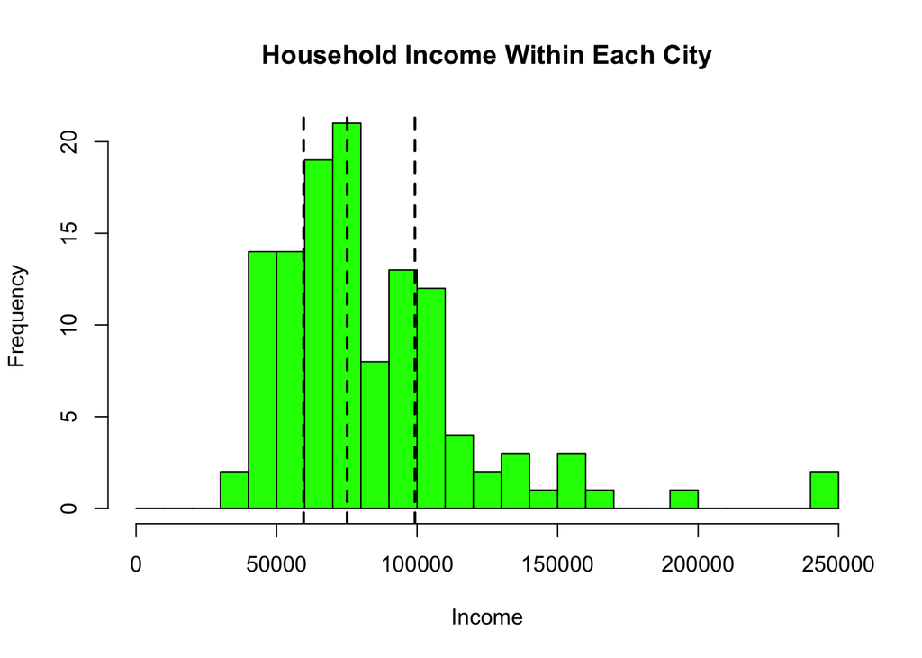

```r
HouseholdIncome <- d$Households
HouseholdIncome.cat <- relevel(as.factor(ifelse(d$Households > quantile(d$Households, probs=.75), "High",
                      ifelse(d$Households < quantile(d$Households, probs=.25), "Low",
                             "Med"))), ref="Med")

hist(HouseholdIncome, breaks=seq(from=0, to=round(max(HouseholdIncome),-2), by=10000), main="Household Income Within Each City", xlab="Income", col="green")
abline(v=quantile(HouseholdIncome, probs=c(.25, .5, .75)), lwd=2, lty=2)
```

# Variables for Analysis

## Distributions

```r
CityAge.m <- cbind(CityAgeOld.cat, CityAgeYoung.cat)
CityRaceEthnicty.m <- cbind(CityHispanic.cat, CityBlack.cat, CityAsian.cat)
d.analysis <- data.frame(Aug.IR, Jan.IR.cat, Aug.Vax.cat, Aug.Vax.percent, CityRaceEthnicty.m, CityAge.m, HouseholdIncome.cat)

summarytools::view(dfSummary(d.analysis, style = 'grid',
                               max.distinct.values = 10, plain.ascii =   FALSE, valid.col = FALSE, headings = FALSE), method = "render")
```

| **No** | **Variable** | **Stats / Values** | **Freqs (% of Valid)** | **Graph** | **Missing** |
| --- | --- | --- | --- | --- | --- |
| 1 | Aug.IR [numeric] | Mean (sd) : 438 (175.2) min ≤ med ≤ max: 39 ≤ 446 ≤ 1082 IQR (CV) : 177.2 (0.4) | 108 distinct values |  | 0 (0.0%) |
| 2 | Jan.IR.cat [factor] | 1. Med 2. High 3. Low | 60 ( 50.0% ) 30 ( 25.0% ) 30 ( 25.0% ) |  | 0 (0.0%) |
| 3 | Aug.Vax.cat [factor] | 1. Med 2. High 3. Low | 62 ( 51.7% ) 30 ( 25.0% ) 28 ( 23.3% ) |  | 0 (0.0%) |
| 4 | Aug.Vax.percent [numeric] | Mean (sd) : 71.1 (11.5) min ≤ med ≤ max: 21 ≤ 72.2 ≤ 93.7 IQR (CV) : 12.5 (0.2) | 104 distinct values |  | 0 (0.0%) |
| 5 | CityHispanic.cat [integer] | Mean (sd) : 1.8 (0.8) min ≤ med ≤ max: 1 ≤ 1.5 ≤ 3 IQR (CV) : 1.2 (0.5) | 1 : 60 ( 50.0% ) 2 : 30 ( 25.0% ) 3 : 30 ( 25.0% ) |  | 0 (0.0%) |
| 6 | CityBlack.cat [integer] | Min : 1 Mean : 1.1 Max : 2 | 1 : 103 ( 85.8% ) 2 : 17 ( 14.2% ) |  | 0 (0.0%) |
| 7 | CityAsian.cat [integer] | Mean (sd) : 1.8 (0.8) min ≤ med ≤ max: 1 ≤ 1.5 ≤ 3 IQR (CV) : 1.2 (0.5) | 1 : 60 ( 50.0% ) 2 : 30 ( 25.0% ) 3 : 30 ( 25.0% ) |  | 0 (0.0%) |
| 8 | CityAgeOld.cat [integer] | Min : 1 Mean : 1.2 Max : 2 | 1 : 90 ( 75.0% ) 2 : 30 ( 25.0% ) |  | 0 (0.0%) |
| 9 | CityAgeYoung.cat [integer] | Min : 1 Mean : 1.2 Max : 2 | 1 : 90 ( 75.0% ) 2 : 30 ( 25.0% ) |  | 0 (0.0%) |
| 10 | HouseholdIncome.cat [factor] | 1. Med 2. High 3. Low | 60 ( 50.0% ) 30 ( 25.0% ) 30 ( 25.0% ) |  | 0 (0.0%) |

Generated by [summarytools](https://urldefense.com/v3/__https://github.com/dcomtois/summarytools__;!!LIr3w8kk_Xxm!42SFJ4mAnuyis5fMPAQR7pZQrdUOdIXm5lYMIzk-GKLmIJg3ELL6B5IHBzsbs7o$) 1.0.0 ([R](https://urldefense.com/v3/__https://www.r-project.org/__;!!LIr3w8kk_Xxm!42SFJ4mAnuyis5fMPAQR7pZQrdUOdIXm5lYMIzk-GKLmIJg3ELL6B5IHZclYyhk$) version 4.1.1)  
2021-10-18

## Correlation

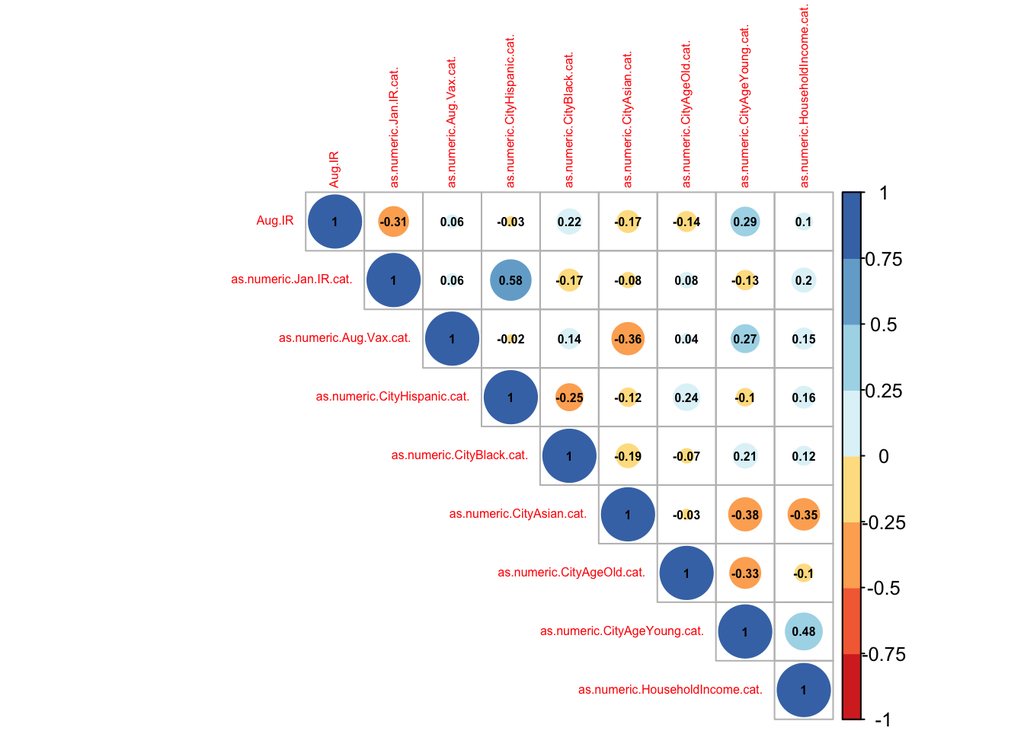

```r
d.num <- data.frame(Aug.IR, as.numeric(Jan.IR.cat), as.numeric(Aug.Vax.cat),
                    as.numeric(CityHispanic.cat), as.numeric(CityBlack.cat), as.numeric(CityAsian.cat),
                    as.numeric(CityAgeOld.cat), as.numeric(CityAgeYoung.cat),
                    as.numeric(HouseholdIncome.cat))
cormat <- cor(d.num, use="complete.obs", method="pearson")
corrplot(cormat, type="upper", order="original",
          col=brewer.pal(n=8, name="RdYlBu"),
          title = "",
          addCoef.col = "black",
          tl.cex=.5, number.cex=.5)
```

# Pairwise Trend Plots

## January IR vs. Proportion of Hispanic Individuals

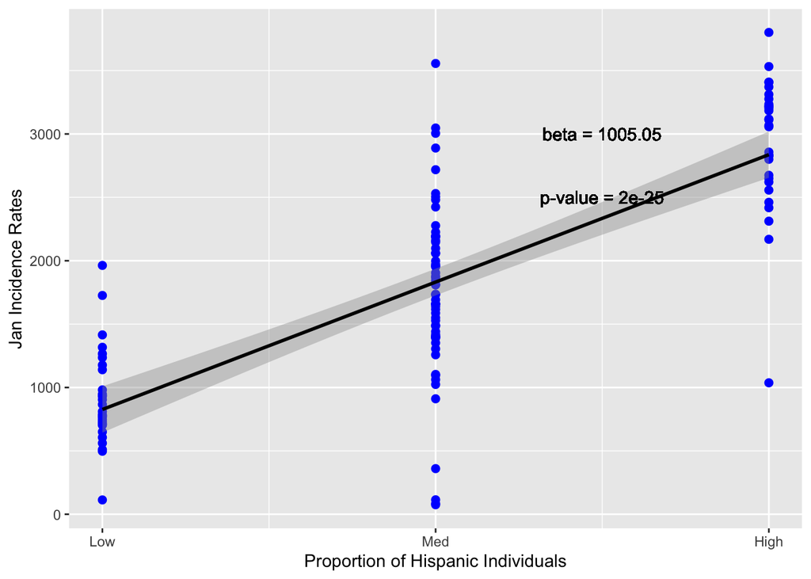

```r
CityHispanic.cont <- as.numeric(relevel(CityHispanic.cat, "Low"))
coef <- summary(lm(Jan.IR~CityHispanic.cont))$coef
ggplot(d.analysis, aes(x=CityHispanic.cont, y=Jan.IR)) +
  geom_point(color="blue", size=2) +
  geom_smooth(method=lm, color="black") +
  geom_text(x=2.5, y=3000, label=paste(expression(beta), "=", round(coef[2,1],2))) +
  geom_text(x=2.5, y=2500, label=paste("p-value", "=", round(coef[2,4],25))) +
  scale_x_continuous(name ="Proportion of Hispanic Individuals", breaks=c(1,2,3), labels=c("Low", "Med", "High"))+
  ylab("Jan Incidence Rates")
```

## January IR vs. Household Income

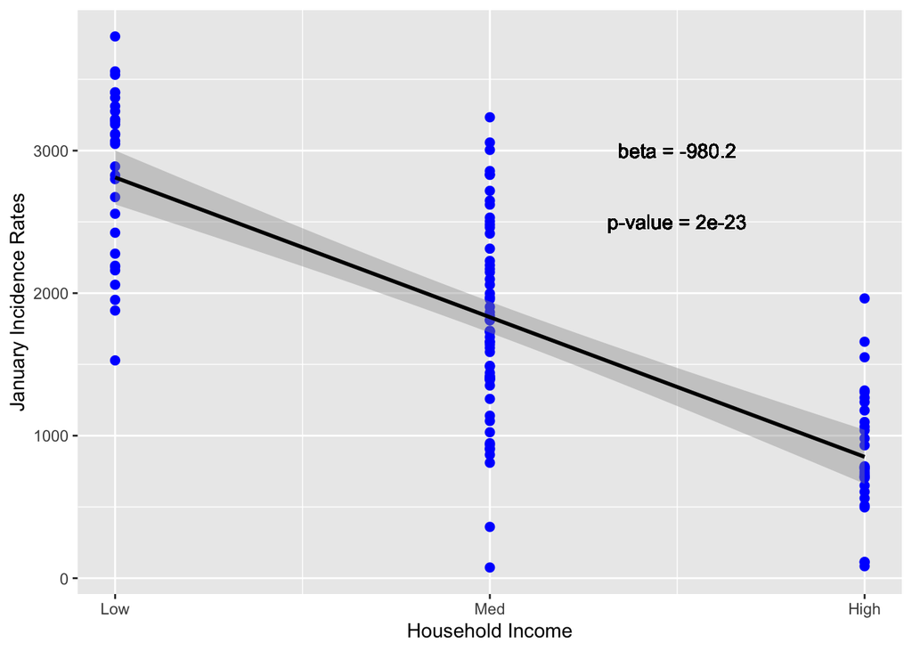

```r
coef <- summary(lm(Jan.IR~as.numeric(relevel(HouseholdIncome.cat, "Low"))))$coef
ggplot(d.analysis, aes(x=as.numeric(relevel(HouseholdIncome.cat, "Low")), y=Jan.IR)) +
  geom_point(color="blue", size=2) +
  geom_smooth(method=lm, color="black") +
  geom_text(x=2.5, y=3000, label=paste(expression(beta), "=", round(coef[2,1],2))) +
  geom_text(x=2.5, y=2500, label=paste("p-value", "=", round(coef[2,4],23))) +
  scale_x_continuous(name ="Household Income", breaks=c(1,2,3), labels=c("Low", "Med", "High"))+
  ylab("January Incidence Rates")
```

## August IR vs. January IR

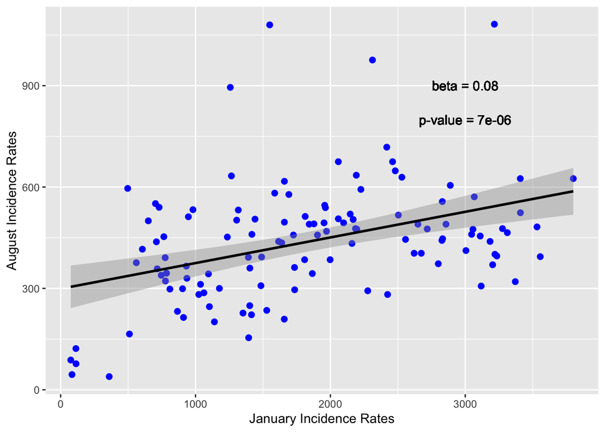

```r
coef <- summary(lm(Aug.IR~Jan.IR))$coef
ggplot(d.analysis, aes(x=Jan.IR, y=Aug.IR)) +
  geom_point(color="blue", size=2) +
  geom_smooth(method=lm, color="black") +
  geom_text(x=3000, y=900, label=paste(expression(beta), "=", round(coef[2,1],2))) +
  geom_text(x=3000, y=800, label=paste("p-value", "=", round(coef[2,4],6)))+
  xlab("January Incidence Rates")+ylab("August Incidence Rates")
```

## August IR vs. Proportion of Hispanic Individuals

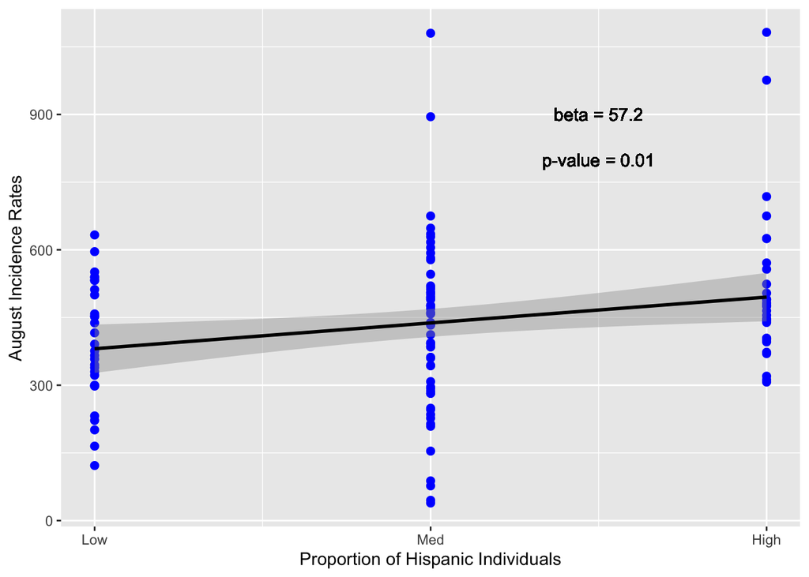

```r
CityHispanic.cont <- as.numeric(relevel(CityHispanic.cat, "Low"))
coef <- summary(lm(Aug.IR~CityHispanic.cont))$coef
ggplot(d.analysis, aes(x=CityHispanic.cont, y=Aug.IR)) +
  geom_point(color="blue", size=2) +
  geom_smooth(method=lm, color="black") +
  geom_text(x=2.5, y=900, label=paste(expression(beta), "=", round(coef[2,1],2))) +
  geom_text(x=2.5, y=800, label=paste("p-value", "=", round(coef[2,4],2))) +
  scale_x_continuous(name ="Proportion of Hispanic Individuals", breaks=c(1,2,3), labels=c("Low", "Med", "High"))+
  ylab("August Incidence Rates")
```

## August IR vs. Household Income

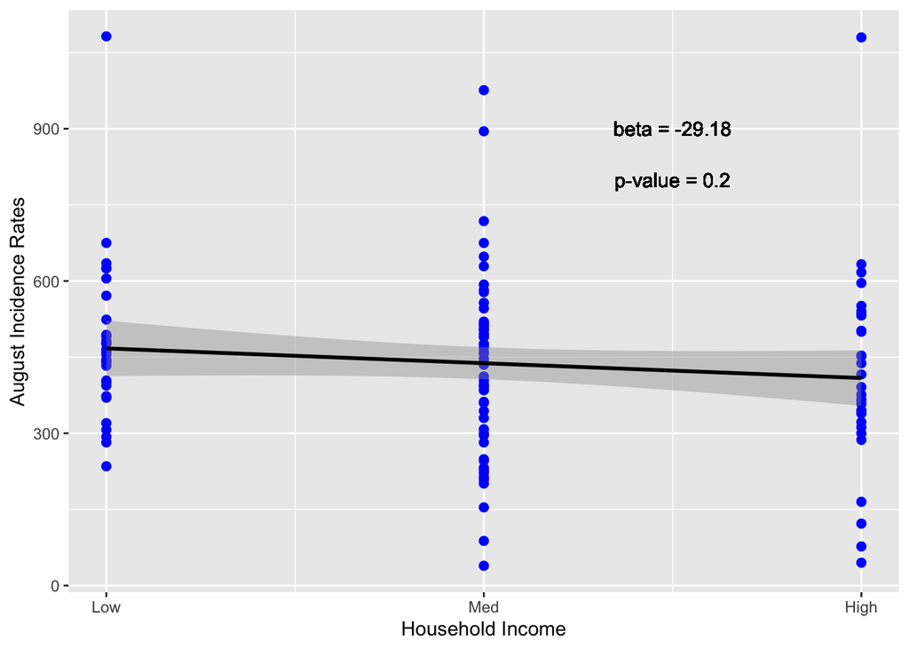

```r
coef <- summary(lm(Aug.IR~as.numeric(relevel(HouseholdIncome.cat, "Low"))))$coef
ggplot(d.analysis, aes(x=as.numeric(relevel(HouseholdIncome.cat, "Low")), y=Aug.IR)) +
  geom_point(color="blue", size=2) +
  geom_smooth(method=lm, color="black") +
  geom_text(x=2.5, y=900, label=paste(expression(beta), "=", round(coef[2,1],2))) +
  geom_text(x=2.5, y=800, label=paste("p-value", "=", round(coef[2,4],2))) +
  scale_x_continuous(name ="Household Income", breaks=c(1,2,3), labels=c("Low", "Med", "High"))+
  ylab("August Incidence Rates")
```

## August IR vs. August Percent Vaccinated

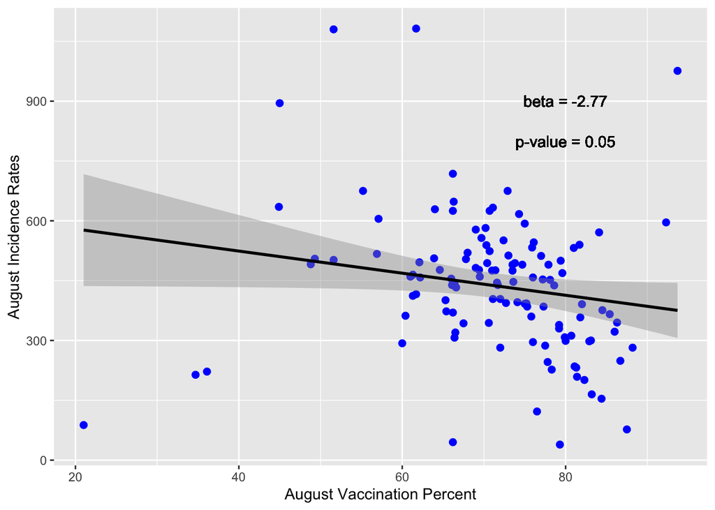

```r
coef <- summary(lm(Aug.IR~Aug.Vax.percent))$coef
ggplot(d.analysis, aes(x=Aug.Vax.percent, y=Aug.IR)) +
  geom_point(color="blue", size=2) +
  geom_smooth(method=lm, color="black") +
  geom_text(x=80, y=900, label=paste(expression(beta), "=", round(coef[2,1],2))) +
  geom_text(x=80, y=800, label=paste("p-value", "=", round(coef[2,4],2)))+
  xlab("August Vaccination Percent")+ylab("August Incidence Rates")
```

# January Incident Rates:

## Regression Model

```r
reg.Jan.noVax <- lm(Jan.IR ~ HouseholdIncome.cat+CityRaceEthnicty.m+CityAge.m)
```

### Regression summary

```r
kable(summary(reg.Jan.noVax)$coef, digits=3, format = "simple", align = 'c', caption = "January Regression")
```

January Regression

|  | Estimate | Std. Error | t value | Pr(>\|t\|) |
| --- | --- | --- | --- | --- |
| (Intercept) | 1143.251 | 444.171 | 2.574 | 0.011 |
| HouseholdIncome.catHigh | -869.050 | 165.789 | -5.242 | 0.000 |
| HouseholdIncome.catLow | 799.675 | 164.726 | 4.855 | 0.000 |
| CityRaceEthnicty.mCityHispanic.cat | 58.610 | 79.713 | 0.735 | 0.464 |
| CityRaceEthnicty.mCityBlack.cat | 53.620 | 166.905 | 0.321 | 0.749 |
| CityRaceEthnicty.mCityAsian.cat | 75.301 | 74.948 | 1.005 | 0.317 |
| CityAge.mCityAgeOld.cat | -119.060 | 149.029 | -0.799 | 0.426 |
| CityAge.mCityAgeYoung.cat | 447.191 | 166.440 | 2.687 | 0.008 |

```r
#stargazer(reg.Jan.noVax, type = 'html', ci=TRUE, ci.level=0.95, single.row = T)
```

### Regression ANOVA

$R^2 =$ 0.61

```r
kable(anova(reg.Jan.noVax), digits=3, format = "simple", align = 'c', caption = "January Regression ANOVA")
```

January Regression ANOVA

|  | Df | Sum Sq | Mean Sq | F value | Pr(>F) |
| --- | --- | --- | --- | --- | --- |
| HouseholdIncome.cat | 2 | 57750787.6 | 28875393.80 | 81.696 | 0.000 |
| CityRaceEthnicty.m | 3 | 238425.8 | 79475.28 | 0.225 | 0.879 |
| CityAge.m | 2 | 3169937.1 | 1584968.55 | 4.484 | 0.013 |
| Residuals | 112 | 39586099.9 | 353447.32 | NA | NA |

# August Incident Rates:

## Vaccination Only

### Regression Model

```r
reg.Aug.vax <- lm(Aug.IR ~ Aug.Vax.cat)
```

#### Regression summary

```r
kable(summary(reg.Aug.vax)$coef, digits=3, format = "simple", align = 'c', caption = "August Regression")
```

August Regression

|  | Estimate | Std. Error | t value | Pr(>\|t\|) |
| --- | --- | --- | --- | --- |
| (Intercept) | 452.264 | 21.196 | 21.338 | 0.000 |
| Aug.Vax.catHigh | -106.564 | 37.118 | -2.871 | 0.005 |
| Aug.Vax.catLow | 53.201 | 38.000 | 1.400 | 0.164 |

#### Regression ANOVA

$R^2 =$ 0.11

```r
kable(anova(reg.Aug.vax), digits=3, format = "simple", align = 'c', caption = "August Regression ANOVA")
```

August Regression ANOVA

|  | Df | Sum Sq | Mean Sq | F value | Pr(>F) |
| --- | --- | --- | --- | --- | --- |
| Aug.Vax.cat | 2 | 395632.6 | 197816.30 | 7.102 | 0.001 |
| Residuals | 117 | 3258889.0 | 27853.75 | NA | NA |

## Full Model

### Regression Model

```r
reg.Aug <- lm(Aug.IR ~ Aug.Vax.cat + Jan.IR.cat + HouseholdIncome.cat+CityRaceEthnicty.m+CityAge.m)
```

#### Regression summary

```r
kable(summary(reg.Aug)$coef, digits=3, format = "simple", align = 'c', caption = "August Regression")
```

August Regression

|  | Estimate | Std. Error | t value | Pr(>\|t\|) |
| --- | --- | --- | --- | --- |
| (Intercept) | 343.510 | 116.087 | 2.959 | 0.004 |
| Aug.Vax.catHigh | -50.255 | 40.583 | -1.238 | 0.218 |
| Aug.Vax.catLow | 34.856 | 40.181 | 0.867 | 0.388 |
| Jan.IR.catHigh | -14.065 | 45.636 | -0.308 | 0.759 |
| Jan.IR.catLow | -209.172 | 48.040 | -4.354 | 0.000 |
| HouseholdIncome.catHigh | 101.006 | 47.314 | 2.135 | 0.035 |
| HouseholdIncome.catLow | -68.210 | 48.004 | -1.421 | 0.158 |
| CityRaceEthnicty.mCityHispanic.cat | 52.054 | 23.834 | 2.184 | 0.031 |
| CityRaceEthnicty.mCityBlack.cat | 85.792 | 43.177 | 1.987 | 0.049 |
| CityRaceEthnicty.mCityAsian.cat | -16.961 | 20.538 | -0.826 | 0.411 |
| CityAge.mCityAgeOld.cat | -65.355 | 39.377 | -1.660 | 0.100 |
| CityAge.mCityAgeYoung.cat | 55.123 | 45.150 | 1.221 | 0.225 |

#### Regression ANOVA

$R^2 =$ 0.31

```r
kable(anova(reg.Aug), digits=3, format = "simple", align = 'c', caption = "August Regression ANOVA")
```

August Regression ANOVA

|  | Df | Sum Sq | Mean Sq | F value | Pr(>F) |
| --- | --- | --- | --- | --- | --- |
| Aug.Vax.cat | 2 | 395632.6 | 197816.30 | 8.437 | 0.000 |
| Jan.IR.cat | 2 | 212026.2 | 106013.10 | 4.522 | 0.013 |
| HouseholdIncome.cat | 2 | 162540.1 | 81270.07 | 3.466 | 0.035 |
| CityRaceEthnicty.m | 3 | 228616.0 | 76205.34 | 3.250 | 0.025 |
| CityAge.m | 2 | 123601.5 | 61800.74 | 2.636 | 0.076 |
| Residuals | 108 | 2532105.2 | 23445.42 | NA | NA |

# August Vaccination Rates:

## Regression Model with August Vaccination

```r
reg.Aug.vax <- lm(Aug.Vax.percent ~ Jan.IR.cat+HouseholdIncome.cat+CityRaceEthnicty.m+CityAge.m)
```

### Regression summary

```r
kable(summary(reg.Aug.vax)$coef, digits=3, format = "simple", align = 'c', caption = "August Vaccination Regression")
```

August Vaccination Regression

|  | Estimate | Std. Error | t value | Pr(>\|t\|) |
| --- | --- | --- | --- | --- |
| (Intercept) | 62.524 | 7.663 | 8.160 | 0.000 |
| Jan.IR.catHigh | -0.373 | 2.960 | -0.126 | 0.900 |
| Jan.IR.catLow | 0.653 | 3.018 | 0.217 | 0.829 |
| HouseholdIncome.catHigh | 2.272 | 3.113 | 0.730 | 0.467 |
| HouseholdIncome.catLow | 0.366 | 3.164 | 0.116 | 0.908 |
| CityRaceEthnicty.mCityHispanic.cat | 4.351 | 1.525 | 2.854 | 0.005 |
| CityRaceEthnicty.mCityBlack.cat | 1.762 | 2.851 | 0.618 | 0.538 |
| CityRaceEthnicty.mCityAsian.cat | 3.986 | 1.294 | 3.081 | 0.003 |
| CityAge.mCityAgeOld.cat | -1.635 | 2.590 | -0.631 | 0.529 |
| CityAge.mCityAgeYoung.cat | -5.378 | 2.898 | -1.856 | 0.066 |

### Regression ANOVA

```r
kable(anova(reg.Aug.vax), digits=3, format = "simple", align = 'c', caption = "August Vaccination Regression ANOVA")
```

August Vaccination Regression ANOVA

|  | Df | Sum Sq | Mean Sq | F value | Pr(>F) |
| --- | --- | --- | --- | --- | --- |
| Jan.IR.cat | 2 | 1255.513 | 627.757 | 6.106 | 0.003 |
| HouseholdIncome.cat | 2 | 775.749 | 387.874 | 3.773 | 0.026 |
| CityRaceEthnicty.m | 3 | 2046.386 | 682.129 | 6.635 | 0.000 |
| CityAge.m | 2 | 361.369 | 180.685 | 1.758 | 0.177 |
| Residuals | 110 | 11308.186 | 102.802 | NA | NA |

## Multnomial Regression Model with August Vaccination

```r
reg.Aug.vax <- lm(Aug.Vax.percent ~ Jan.IR.cat+HouseholdIncome.cat+CityRaceEthnicty.m+CityAge.m)
reg.Aug.vax <- multinom(Aug.Vax.cat ~ Jan.IR.cat+HouseholdIncome.cat+CityRaceEthnicty.m+CityAge.m)
```

### Regression summary for High Vaccination Rates

```r
coef.high <- summary(reg.Aug.vax)$coefficients["High",]
OR.high <- exp(coef.high)
se.high <- summary(reg.Aug.vax)$standard.errors["High",]
z.high <- coef.high/se.high
p.value.high <- (1 - pnorm(abs(z.high), 0, 1)) * 2
r.high <- data.frame(OR.high, coef.high, se.high, z.high, p.value.high)
kable(r.high, digits=3, format = "simple", align = 'c', caption = "August Vaccination Regression for High Vax Rates")
```

August Vaccination Regression for High Vax Rates

|  | OR.high | coef.high | se.high | z.high | p.value.high |
| --- | --- | --- | --- | --- | --- |
| (Intercept) | 0.199 | -1.615 | 2.599 | -0.621 | 0.534 |
| Jan.IR.catHigh | 0.080 | -2.524 | 1.356 | -1.861 | 0.063 |
| Jan.IR.catLow | 7.436 | 2.006 | 0.749 | 2.680 | 0.007 |
| HouseholdIncome.catHigh | 0.343 | -1.069 | 0.871 | -1.228 | 0.219 |
| HouseholdIncome.catLow | 3.456 | 1.240 | 1.139 | 1.088 | 0.276 |
| CityRaceEthnicty.mCityHispanic.cat | 1.878 | 0.630 | 0.389 | 1.620 | 0.105 |
| CityRaceEthnicty.mCityBlack.cat | 0.310 | -1.172 | 1.227 | -0.955 | 0.339 |
| CityRaceEthnicty.mCityAsian.cat | 1.194 | 0.177 | 0.379 | 0.467 | 0.640 |
| CityAge.mCityAgeOld.cat | 2.161 | 0.770 | 0.672 | 1.146 | 0.252 |
| CityAge.mCityAgeYoung.cat | 0.584 | -0.538 | 1.248 | -0.431 | 0.666 |

### Regression summary for Low Vaccination Rates

```r
coef.low <- summary(reg.Aug.vax)$coefficients["Low",]
OR.low <- exp(coef.low)
se.low <- summary(reg.Aug.vax)$standard.errors["Low",]
z.low <- coef.low/se.low
p.value.low <- (1 - pnorm(abs(z.low), 0, 1)) * 2
r.low <- data.frame(OR.low, coef.low, se.low, z.low, p.value.low)
kable(r.low, digits=3, format = "simple", align = 'c', caption = "August Vaccination Regression for Low Vax Rates")
```

August Vaccination Regression for Low Vax Rates

|  | OR.low | coef.low | se.low | z.low | p.value.low |
| --- | --- | --- | --- | --- | --- |
| (Intercept) | 0.888 | -0.119 | 2.251 | -0.053 | 0.958 |
| Jan.IR.catHigh | 0.506 | -0.681 | 0.910 | -0.748 | 0.454 |
| Jan.IR.catLow | 2.702 | 0.994 | 1.065 | 0.933 | 0.351 |
| HouseholdIncome.catHigh | 0.491 | -0.712 | 1.072 | -0.664 | 0.507 |
| HouseholdIncome.catLow | 1.086 | 0.083 | 0.912 | 0.091 | 0.928 |
| CityRaceEthnicty.mCityHispanic.cat | 0.427 | -0.851 | 0.541 | -1.574 | 0.116 |
| CityRaceEthnicty.mCityBlack.cat | 1.286 | 0.251 | 0.680 | 0.370 | 0.712 |
| CityRaceEthnicty.mCityAsian.cat | 0.185 | -1.687 | 0.558 | -3.021 | 0.003 |
| CityAge.mCityAgeOld.cat | 2.016 | 0.701 | 0.818 | 0.857 | 0.392 |
| CityAge.mCityAgeYoung.cat | 4.508 | 1.506 | 0.804 | 1.873 | 0.061 |